# Homework 3

Xinyang Geng

2/8/2016

*Source file* ⇒ hw3.Rmd

### 5.4

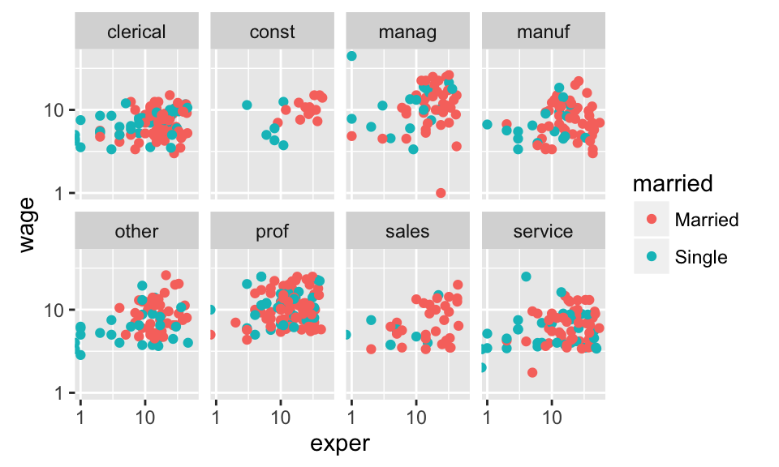

```r
ggplot(data=CPS85,aes(x=exper, y=wage, colour=married)) +
  geom_point() +
  scale_x_log10() +
  scale_y_log10() +
  facet_wrap(~sector,ncol=4)
```

#### Problem 6.2

1. Y axis -> log enzyme concentration X axis at the bottom -> gene flled circle or unfilled circle -> Flux X axis at the top -> target color -> molecule
2. Y axis -> log enzyme concentration X axis at the bottom -> gene Filled circle or unfilled circle: Flux X axis at the top -> target color -> molecule
3. log enzyme concentration and gene
4. gene and target

#### 6.3

1. For the candle stick: x position -> position in the table, y position of the low end of the bar ->low, y position of the high end of the bar ->high, y position of the dot -> center, name of the protein and the color -> polarity. The asterisk glyph: x position -> position in the table, number of asterisk -> signif
2. Y axis: cell density, X axis: protein.
3. No
4. Guides are tick marks for the vertical axis and the label for the horizontal axis.

#### 6.6

D

#### 6.8

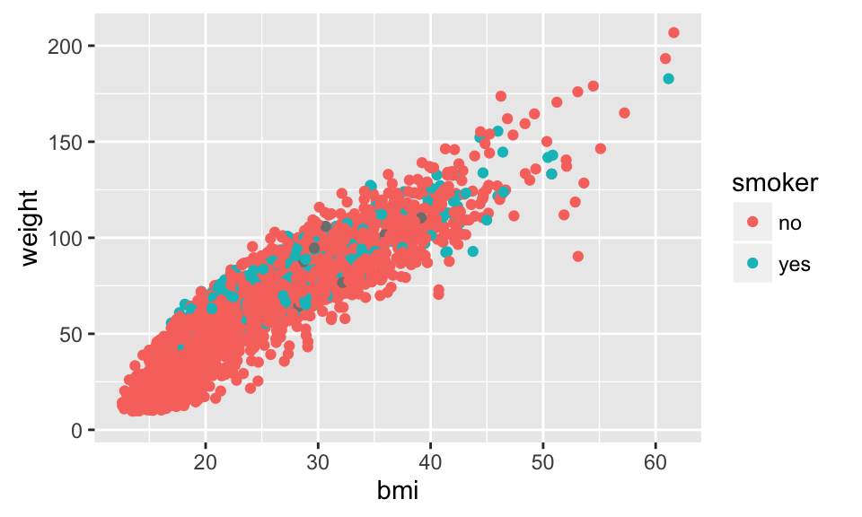

```r
small <-
  NCHS %>%
    sample_n(size=5000)
ggplot(data=small, aes(x=bmi,y=weight)) +
  geom_point() +
  aes(colour=smoker)
```

- Y axis position -> weight
- X axis position -> bmi
- color -> smoker

#### 7.2

```r
diamonds %>%
  group_by(color) %>%
  summarise(avesize=mean(carat, na.rm=TRUE)) %>%
  arrange(desc(avesize)) %>%
  head(1)
```

```
## Source: local data frame [1 x 2]
##
##    color  avesize
##   (fctr)    (dbl)
## 1      J 1.162137
```

The color J has the largest size on average.

```r
diamonds %>%
  group_by(clarity) %>%
  mutate(ratio=table / mean(carat, na.rm=TRUE)) %>%
  arrange(desc(ratio)) %>%
  head(1)
```

```
## Source: local data frame [1 x 11]
## Groups: clarity [1]
##
##   carat    cut  color clarity depth table price     x     y     z    ratio
##   (dbl) (fctr) (fctr)  (fctr) (dbl) (dbl) (int) (dbl) (dbl) (dbl)    (dbl)
## 1  1.45   Fair      F      I1  64.8    67  4320  7.16     7  4.64 52.18694
```

#### 7.4

1. The variable First should not be in parenthesis.
2. The name Tmp is not defined.
3. Should summarise Tmp rather than BabyName.

#### 7.5

- 1. `arrange(count,sex)`
- 2. `filter(sex=="F")`
- 3. `filter(sex=="M", count>10)`
- 4. `summarise(total = sum(count))`
- 5. `select(name, count)`

#### 7.6

1. There are 80101 cases
2. The top 5 are:

```
## Source: local data frame [5 x 2]
##
##               Second count
##                (chr) (int)
## 1       BETSY HODGES 14399
## 2        DON SAMUELS 14170
## 3        MARK ANDREW 12757
## 4 JACKIE CHERRYHOMES  6470
## 5           BOB FINE  3751
```

3. There are 834 ballots marked undervote in the first choice selections, and 10598 in the second, 19210 in the third.
4. The most popular combinations are:

```r
within(Minneapolis2013 %>% select(First, Second), Combination <- paste(First, Second, sep='&')) %>%
  group_by(Combination)%>%
  summarise(count=n())%>%
  arrange(desc(count))%>%
  head(3)
```

```
## Source: local data frame [3 x 2]
##
##                Combination count
##                      (chr) (int)
## 1 BETSY HODGES&MARK ANDREW  8787
## 2 BETSY HODGES&DON SAMUELS  8743
## 3 MARK ANDREW&BETSY HODGES  6970
```

```r
Minneapolis2013 %>%
  group_by(Precinct) %>%
  summarise(count=n()) %>%
  arrange(desc(count)) %>%
  head(1)
```

```
## Source: local data frame [1 x 2]
##
##   Precinct count
##      (chr) (int)
## 1     P-06  9711
```

P-06 is the precinct with the highest number of ballots.

#### 8.1

1. Construct the graphics frame: c
2. Add a layer of glyphs: a, b, g
3. Set axis lable: e
4. Divide the frame into facets: f,i
5. Change the scale for the frame: d, h

#### 8.2

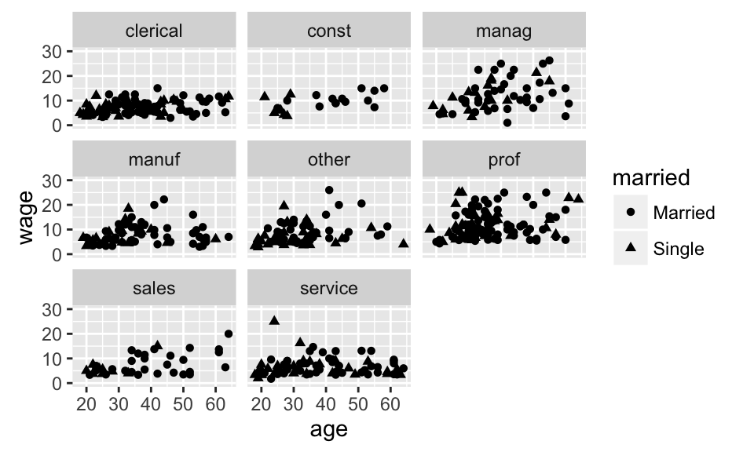

```r
data("CPS85", package="mosaicData")
ggplot(data=CPS85, aes(x=age, y=wage)) +
  geom_point(aes(shape=married)) +
  facet_wrap(~sector, ncol=3) +
  ylim(0, 30)
```

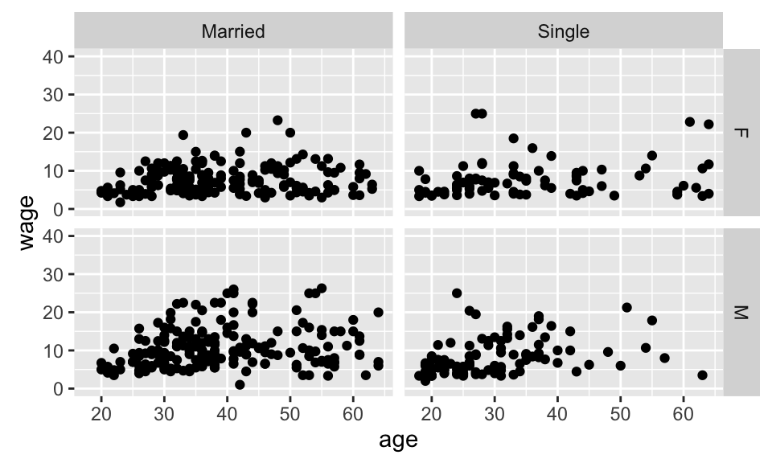

```r
ggplot(data=CPS85, aes(x=age, y=wage)) +
  geom_point() +
  facet_grid(sex~married) +
  ylim(0, 40)
```